# Looking at Visual Statistics with `ggdibbler`

## Any aesthetic!

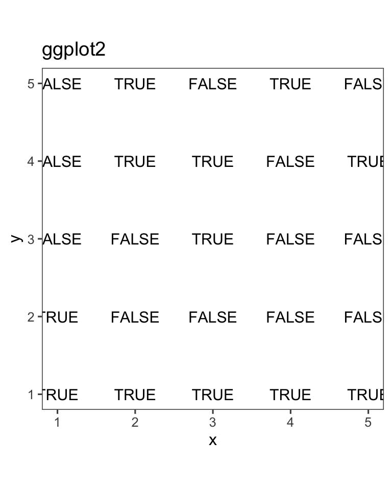

```r
ggplot(textdata, aes(x=x, y=y)) +
  geom_text(aes(label = text_const), size=4) +
  theme_few() +
  ggtitle("ggplot2") +
  theme(aspect.ratio = 1, legend.position = "none")
```

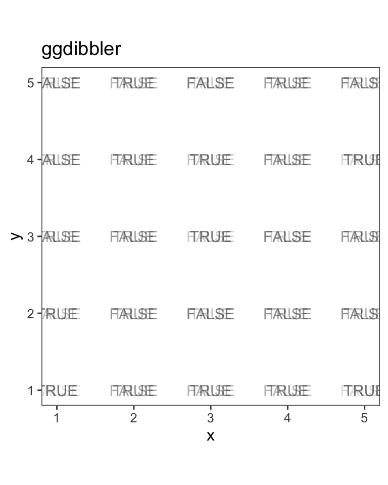

```r
ggplot(textdata, aes(x=x, y=y, lab = text_dist)) +
  geom_text_sample(aes(label = after_stat(lab)), size=4, alpha=1/30, times=30) +
  ggtitle("ggdibbler") +
  theme_few() +
  theme(aspect.ratio = 1, legend.position = "none")
```

## Uhh hold on, positions are an isuse

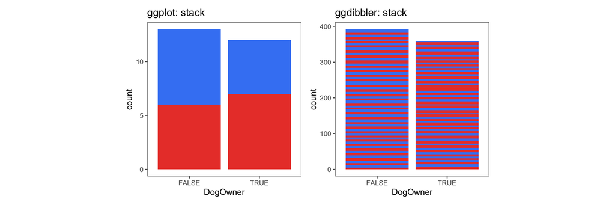

[figure not shown]

## Nested positions!

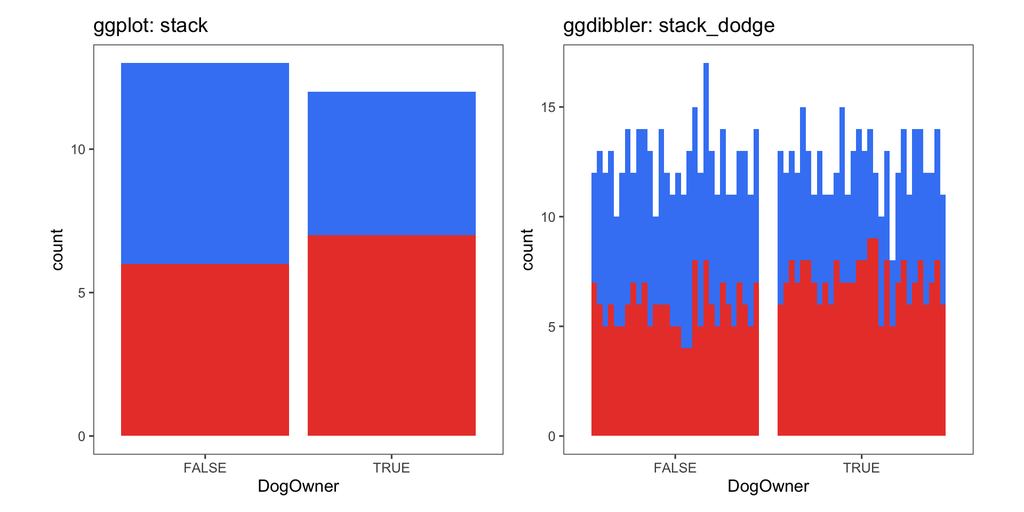

## Any Position!

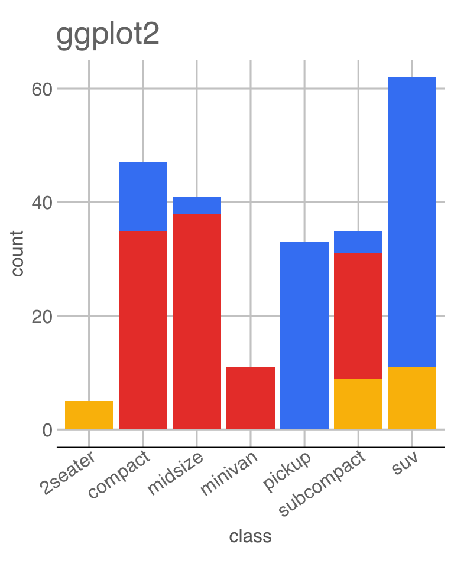

```r
ggplot(mpg, aes(class)) +
  geom_bar_sample(aes(fill = drv),
                  position = "stack")+
  theme(legend.position="none")+
  ggtitle("ggplot2")
```

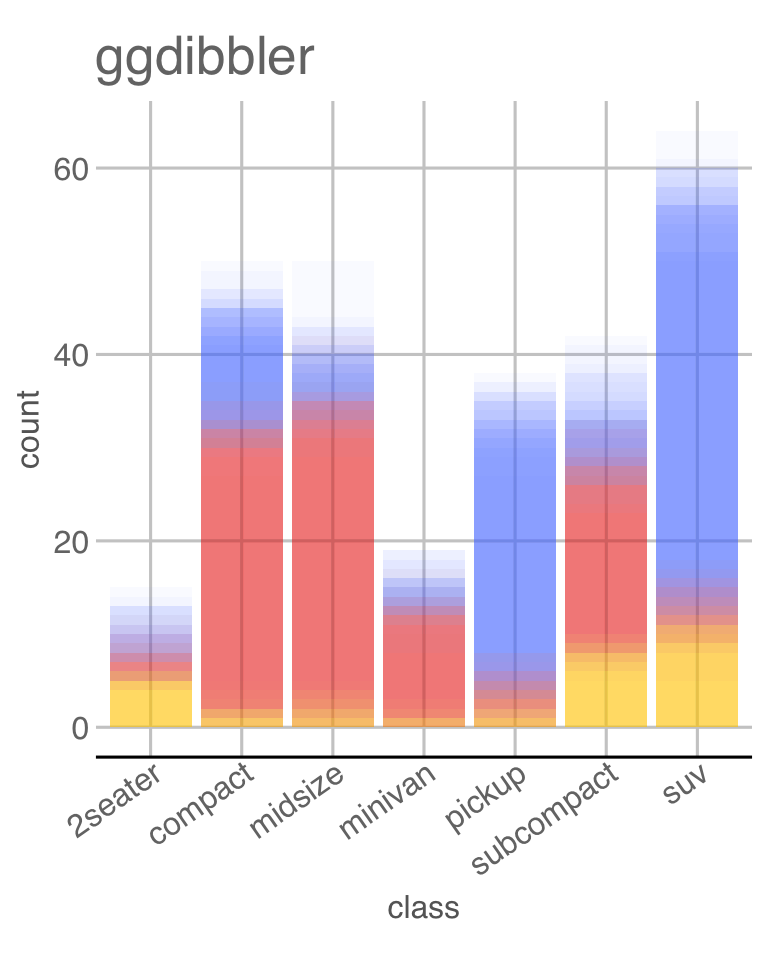

```r
ggplot(uncertain_mpg, aes(class)) +
  geom_bar_sample(aes(fill = drv),times = 30, alpha=1/30,
                  position = "stack_identity")+
  theme(legend.position="none")+
  ggtitle("ggdibbler")
```

## All the documentation!

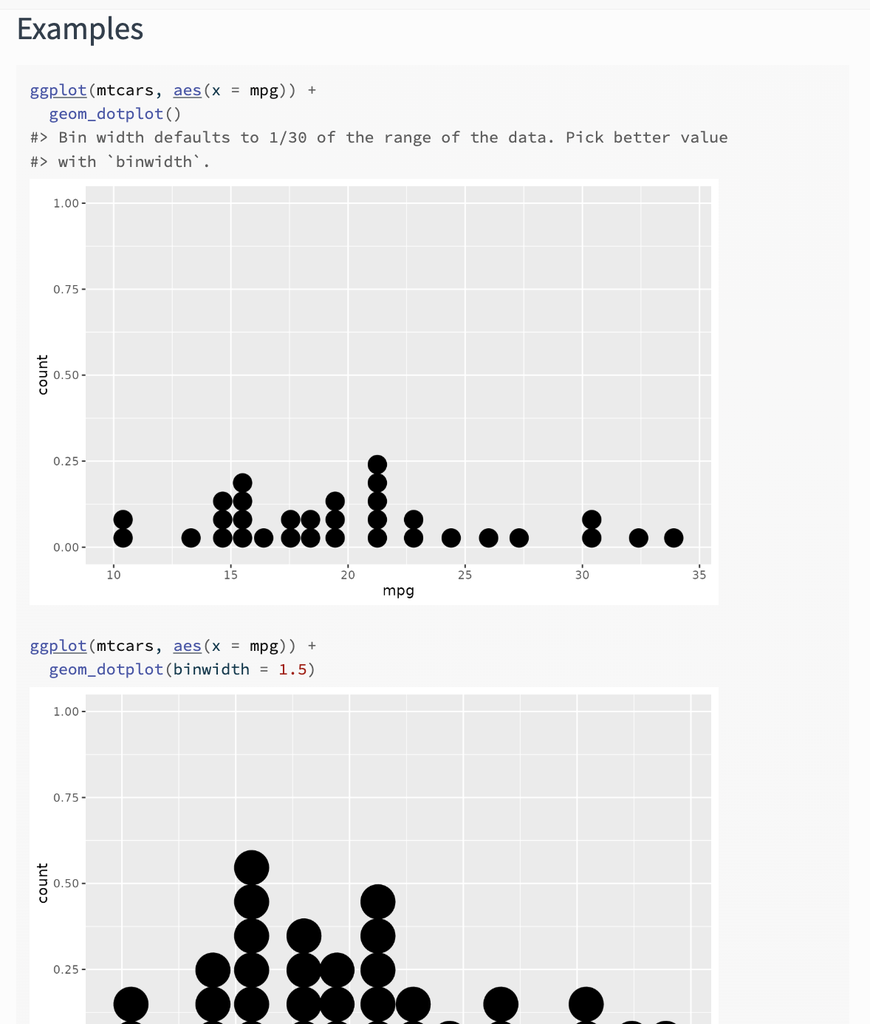

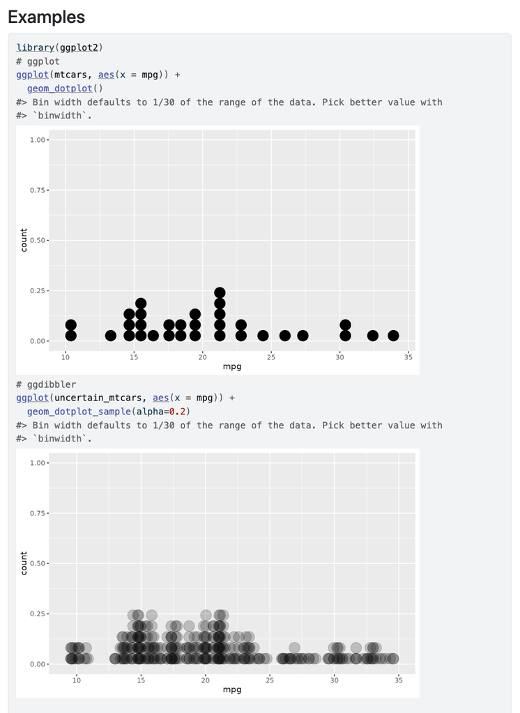

## Combine all this together to get…

[figure not shown]

## Flexible uncertainty visualisation!

[figure not shown]

## Back to walktober example

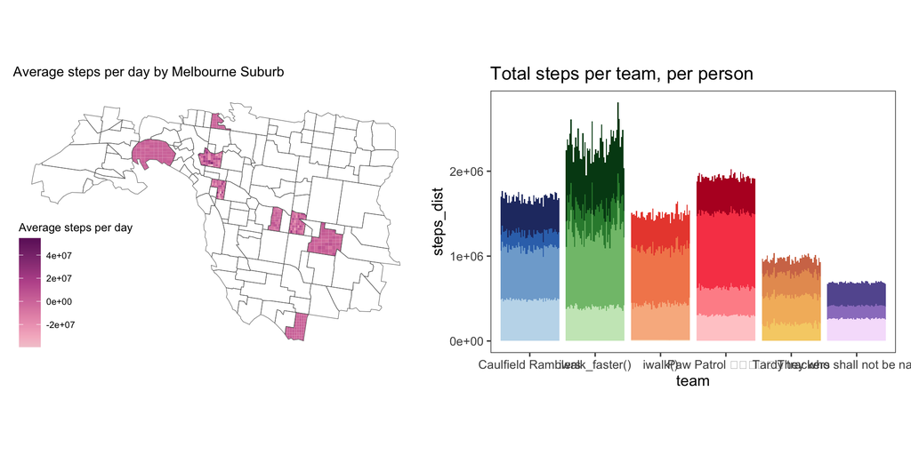

# Bonus: How it works

## Components of the grammar

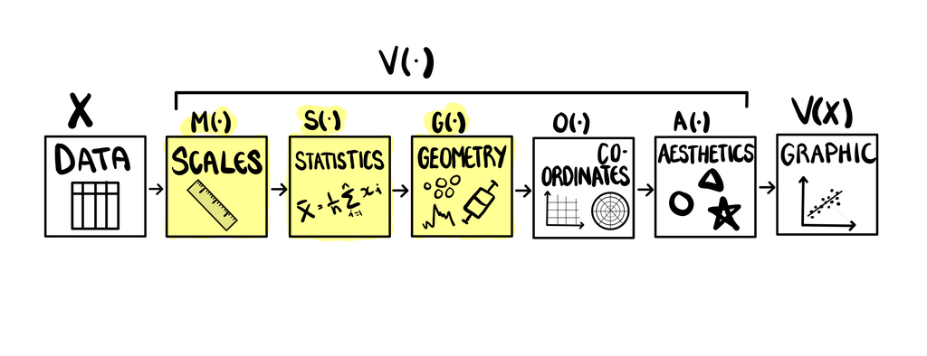

## Scale

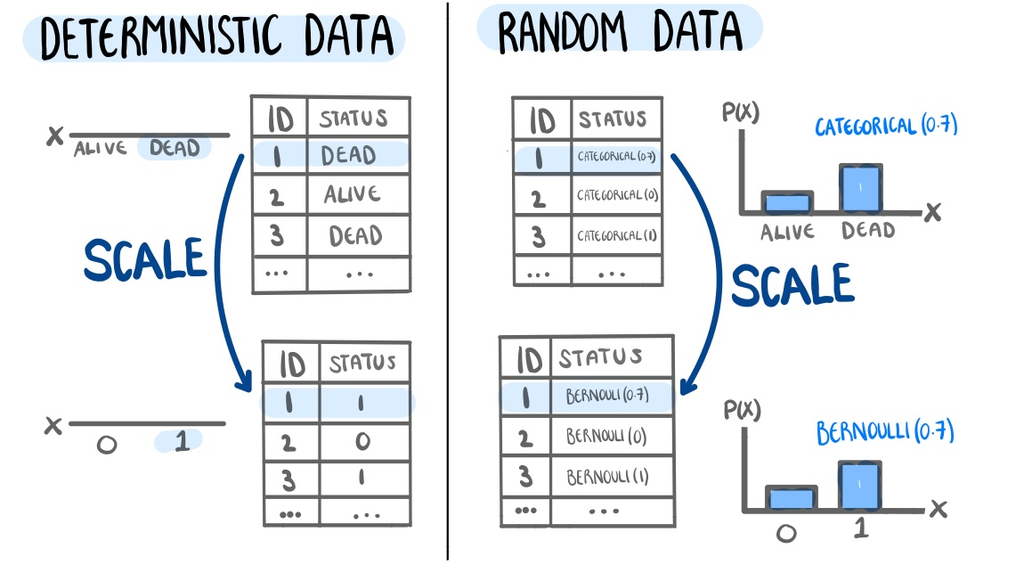

## Statistic

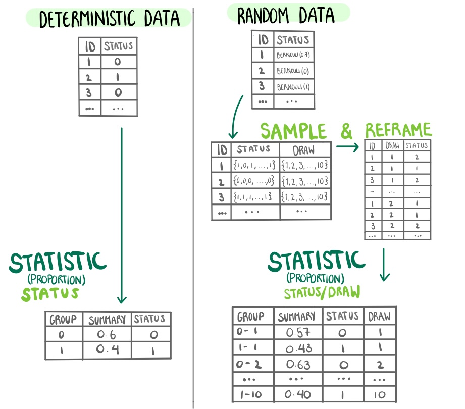

## Why change the groups?

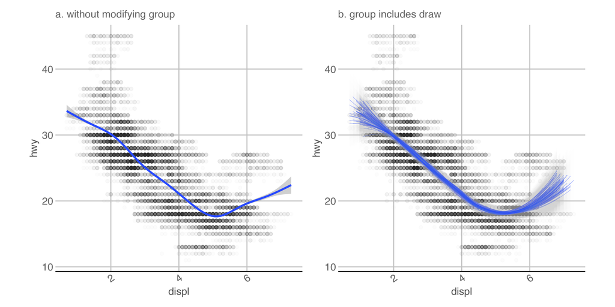

## Position Adjustments

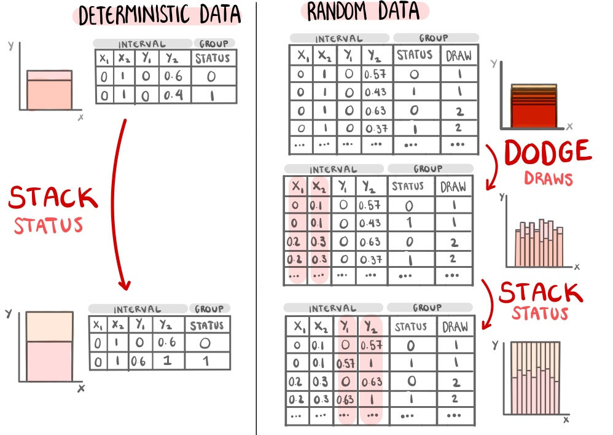

# Conclusion

## Future Plans

- I am open to suggestions!
- Future of the software
  - multivariate distributions
  - build out nested position system
  - expand on the scales to accept more object types
- Want to try and get it working with extensions
  - Looking into `dibble()` function
  - Was thinking of doing the whole thing in scales (to achieve ideal code) but I need to edit the positions as well

## Acknowledgements

- My supervisors: Di Cook, Susan Vanderplas, and Sarah Goodwin
- Good ideas: Mitch O’Hara-Wild and Cynthia Huang
- AEMO Zema Energy Scholarship
- Australian RTP Stipend
- Numbat Hackathon (for the walktober data)